# CFA Produk Lokal - Indonesia

David Syambudi (via GitHub)

## 1 0. Membuat Kuesioner Survei

Gunakan skala Likert 1–5:  
**1 = Sangat Tidak Setuju** sampai **5 = Sangat Setuju**

### 1.1 Kesadaran terhadap Produk Lokal (KPL)

- **KPL1**: Saya mengetahui manfaat menggunakan produk buatan Indonesia.
- **KPL2**: Saya percaya bahwa kualitas produk lokal tidak kalah dengan produk impor.
- **KPL3**: Saya secara aktif mencari informasi tentang produk lokal saat akan berbelanja.

### 1.2 Preferensi Harga (PH)

- **PH1**: Harga yang terjangkau menjadi prioritas utama dalam keputusan pembelian saya.
- **PH2**: Saya cenderung memilih produk dengan harga lebih murah meskipun bukan produk lokal.
- **PH3**: Saya membandingkan harga sebelum memutuskan untuk membeli suatu produk.

### 1.3 Dukungan terhadap UMKM (DUMKM)

- **DUMKM1**: Saya lebih memilih membeli dari usaha kecil dan menengah (UMKM) lokal dibanding merek besar.
- **DUMKM2**: Saya percaya bahwa membeli produk dari UMKM membantu perekonomian Indonesia.
- **DUMKM3**: Saya bersedia membayar lebih jika produk tersebut berasal dari pelaku UMKM lokal.

## 2 1. Import Data dan Validasi

```r
url <- "https://raw.githubusercontent.com/davidsyambudi/Latihan-Kuantitatif/7f19b90036bf567c508c582a80ae5d3343a0d8af/Data_Dummy_Survei_CFA_Produk_Lokal.csv"
data <- read.csv(url)

## Cek nama variabel
names(data)
```

```
## [1] "KPL1"   "KPL2"   "KPL3"   "PH1"    "PH2"    "PH3"    "DUMKM1" "DUMKM2"
## [9] "DUMKM3"
```

```r
## Pastikan semua indikator tersedia
expected_vars <- c("KPL1", "KPL2", "KPL3", "PH1", "PH2", "PH3", "DUMKM1", "DUMKM2", "DUMKM3")
missing_vars <- setdiff(expected_vars, names(data))
if (length(missing_vars) > 0) {
  stop(paste("Variabel hilang dari data:", paste(missing_vars, collapse = ", ")))
}

## Cek nilai unik per variabel
apply(data[, expected_vars], 2, function(x) length(unique(x)))
```

```
##   KPL1   KPL2   KPL3    PH1    PH2    PH3 DUMKM1 DUMKM2 DUMKM3
##      4      4      3      5      5      4      4      3      4
```

## 3 2. Struktur Model CFA Awal

```r
model_cfa <- '
  Kesadaran =~ KPL1 + KPL2 + KPL3
  Harga =~ PH1 + PH2 + PH3
  UMKM =~ DUMKM1 + DUMKM2 + DUMKM3
'
```

## 4 3. Estimasi Model CFA

```r
fit_cfa <- cfa(model_cfa, data = data, std.lv = TRUE)
summary(fit_cfa, fit.measures = TRUE, standardized = TRUE)
```

```
## lavaan 0.6-19 ended normally after 592 iterations
##
##   Estimator                                         ML
##   Optimization method                           NLMINB
##   Number of model parameters                        21
##
##   Number of observations                           200
##
## Model Test User Model:
##
##   Test statistic                                30.219
##   Degrees of freedom                                24
##   P-value (Chi-square)                           0.178
##
## Model Test Baseline Model:
##
##   Test statistic                                50.646
##   Degrees of freedom                                36
##   P-value                                        0.054
##
## User Model versus Baseline Model:
##
##   Comparative Fit Index (CFI)                    0.575
##   Tucker-Lewis Index (TLI)                       0.363
##
## Loglikelihood and Information Criteria:
##
##   Loglikelihood user model (H0)              -1946.096
##   Loglikelihood unrestricted model (H1)      -1930.986
##
##   Akaike (AIC)                                3934.192
##   Bayesian (BIC)                              4003.457
##   Sample-size adjusted Bayesian (SABIC)       3936.926
##
## Root Mean Square Error of Approximation:
##
##   RMSEA                                          0.036
##   90 Percent confidence interval - lower         0.000
##   90 Percent confidence interval - upper         0.071
##   P-value H_0: RMSEA <= 0.050                    0.704
```

[output cut: 34 more lines]

```
##
## Variances:
##                    Estimate  Std.Err  z-value  P(>|z|)   Std.lv  Std.all
##    .KPL1              0.575       NA                      0.575    1.000
##    .KPL2              0.622       NA                      0.622    1.000
##    .KPL3              0.348       NA                      0.348    1.000
##    .PH1               0.703       NA                      0.703    1.000
##    .PH2             -28.542       NA                    -28.542  -39.609
##    .PH3               0.543       NA                      0.543    1.000
##    .DUMKM1            0.209       NA                      0.209    0.460
##    .DUMKM2            0.295       NA                      0.295    0.938
##    .DUMKM3            0.517       NA                      0.517    0.994
##     Kesadaran         1.000                               1.000    1.000
##     Harga             1.000                               1.000    1.000
##     UMKM              1.000                               1.000    1.000
```

## 5 4. Evaluasi Goodness of Fit

```r
fitMeasures(fit_cfa, c("chisq", "df", "pvalue", "cfi", "tli", "rmsea", "srmr"))
```

```
##  chisq     df pvalue    cfi    tli  rmsea   srmr
## 30.219 24.000  0.178  0.575  0.363  0.036  0.057
```

## 6 5. Visualisasi Model

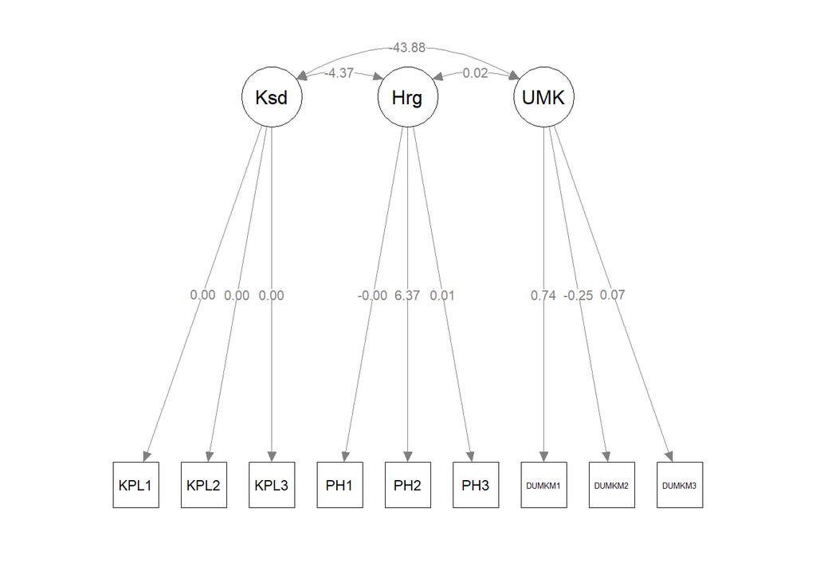

```r
semPaths(fit_cfa,
         whatLabels = "std",
         layout = "tree",
         edge.label.cex = 0.8,
         fade = FALSE,
         residuals = FALSE,
         sizeMan = 6)
```

## 7 6. Evaluasi Modification Indices (MI) – Aman terhadap Error

```r
# Menghindari error 'information matrix is singular'
modindices_df <- tryCatch({
  modindices(fit_cfa, free = TRUE)
}, error = function(e) {
  message("Gagal menghitung Modification Indices karena matrix singular.")
  return(data.frame())
})
```

```
## Gagal menghitung Modification Indices karena matrix singular.
```

```r
## Tampilkan MI > 10 jika berhasil
if (nrow(modindices_df) > 0) {
  modindices_df %>%
    filter(mi > 10) %>%
    arrange(desc(mi)) %>%
    head(10)
} else {
  message("Tidak ada MI yang ditampilkan karena error.")
}
```

```
## Tidak ada MI yang ditampilkan karena error.
```

```r
model_cfa_modified <- '
  Kesadaran =~ KPL1 + KPL2 + KPL3
  Harga =~ PH1 + PH2 + PH3
  UMKM =~ DUMKM1 + DUMKM2 + DUMKM3

  ## Korelasi residual berdasarkan MI (jika ditemukan relevan)
  KPL2 ~~ KPL3
  PH1 ~~ PH3
'

fit_cfa_mod <- cfa(model_cfa_modified, data = data, std.lv = TRUE)
summary(fit_cfa_mod, fit.measures = TRUE, standardized = TRUE)
```

```
## lavaan 0.6-19 ended normally after 8194 iterations
##
##   Estimator                                         ML
##   Optimization method                           NLMINB
##   Number of model parameters                        23
##
##   Number of observations                           200
##
## Model Test User Model:
##
##   Test statistic                                28.198
##   Degrees of freedom                                22
##   P-value (Chi-square)                           0.169
##
## Model Test Baseline Model:
##
##   Test statistic                                50.646
##   Degrees of freedom                                36
##   P-value                                        0.054
##
## User Model versus Baseline Model:
##
##   Comparative Fit Index (CFI)                    0.577
##   Tucker-Lewis Index (TLI)                       0.308
##
## Loglikelihood and Information Criteria:
##
##   Loglikelihood user model (H0)              -1945.085
##   Loglikelihood unrestricted model (H1)      -1930.986
##
##   Akaike (AIC)                                3936.170
##   Bayesian (BIC)                              4012.032
##   Sample-size adjusted Bayesian (SABIC)       3939.165
##
## Root Mean Square Error of Approximation:
##
##   RMSEA                                          0.038
##   90 Percent confidence interval - lower         0.000
##   90 Percent confidence interval - upper         0.074
##   P-value H_0: RMSEA <= 0.050                    0.672
```

[output cut: 38 more lines]

```
##
## Variances:
##                    Estimate  Std.Err  z-value  P(>|z|)   Std.lv  Std.all
##    .KPL1              0.413       NA                      0.413    0.719
##    .KPL2              0.611       NA                      0.611    0.983
##    .KPL3              0.348       NA                      0.348    1.000
##    .PH1               0.689       NA                      0.689    0.979
##    .PH2               0.698       NA                      0.698    0.970
##    .PH3               0.424       NA                      0.424    0.780
##    .DUMKM1            0.454       NA                      0.454    1.000
##    .DUMKM2         -315.300       NA                   -315.300 -999.603
##    .DUMKM3            0.520       NA                      0.520    1.000
##     Kesadaran         1.000                               1.000    1.000
##     Harga             1.000                               1.000    1.000
##     UMKM              1.000                               1.000    1.000
```

## 9 8. Evaluasi Model Setelah Modifikasi

```r
fitMeasures(fit_cfa_mod, c("chisq", "df", "pvalue", "cfi", "tli", "rmsea", "srmr"))
```

```
##  chisq     df pvalue    cfi    tli  rmsea   srmr
## 28.198 22.000  0.169  0.577  0.308  0.038  0.057
```

## 10 9. Visualisasi Model Modifikasi

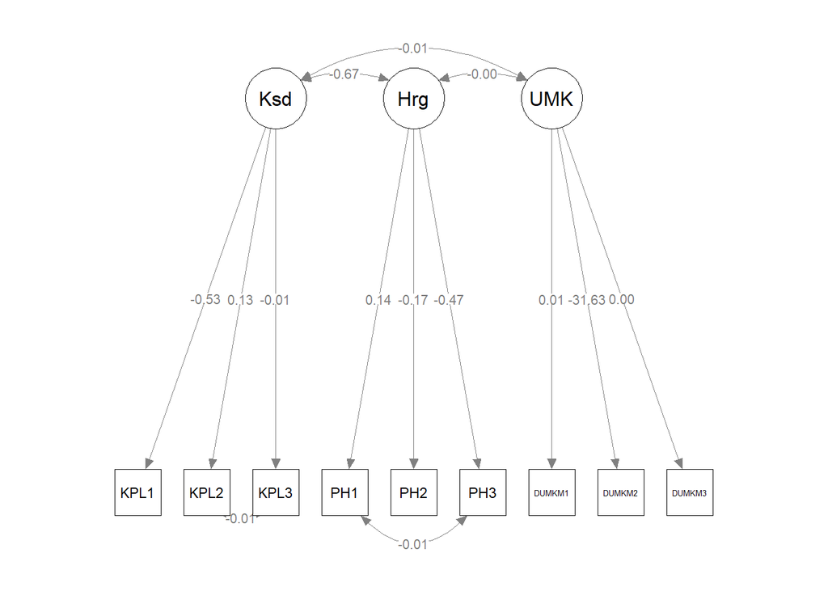

```r
semPaths(fit_cfa_mod,
         whatLabels = "std",
         layout = "tree",
         edge.label.cex = 0.8,
         fade = FALSE,
         residuals = FALSE,
         sizeMan = 6)
```

## 11 10. Kesimpulan

[output not shown]